# Saúde da população negra

Pablo Castro

2026-06-19

# 1 Introdução

As desigualdades em saúde vivenciadas pela população negra no Brasil não decorrem de fatores biológicos, mas de determinantes sociais estruturais que se articulam com o racismo para produzir iniquidades sistemáticas no acesso a serviços, na qualidade do cuidado recebido e nos resultados em saúde. Este texto analisa essas iniquidades a partir de múltiplas dimensões: cobertura de planos de saúde, utilização de serviços de urgência e consulta médica, acesso a medicamentos no sistema público, prevalência de deficiências e diagnósticos de autismo, e uso de serviços de Atenção Primária à Saúde (APS) por crianças.

O conceito de iniquidade em saúde, tal como formulado pela Organização Mundial da Saúde e incorporado à Política Nacional de Saúde Integral da População Negra (PNSIPN), refere-se a diferenças de saúde que são desnecessárias, evitáveis e injustas. No Brasil, o racismo institucional — entendido como o fracasso coletivo de organizações e instituições em oferecer um serviço profissional e adequado às pessoas em virtude de sua cor, cultura ou origem étnica — opera como determinante social de saúde, atravessando desde a formação de profissionais até a distribuição territorial de serviços e equipamentos públicos.

Em conformidade com o Plano de Trabalho Geral, a análise articula dados do Censo Demográfico 2022 (IBGE), da Pesquisa Nacional de Saúde (PNS 2013 e 2019), da Pesquisa Nacional por Amostra de Domicílios Contínua (PNAD-C 2022) e do Sistema de Informações sobre Mortalidade (SIM/DATASUS, 1996–2019), combinando indicadores de acesso, utilização, cobertura e mortalidade por causas, com recorte de raça/cor e dimensão territorial. Os resultados evidenciam desigualdades persistentes que demandam políticas específicas de equidade no SUS.

É importante registrar uma escolha metodológica deliberada: diferentemente de outros textos deste produto, que se apoiam predominantemente no Censo Demográfico 2022, a análise da saúde da população negra recorre principalmente à PNS, à PNAD-C e ao SIM. Essa escolha não decorre de preferência metodológica, mas de uma limitação objetiva da fonte censitária: o Censo 2022 não coleta informações sobre morbidade, mortalidade, utilização de serviços de saúde ou cobertura de planos de saúde — variáveis centrais para o diagnóstico de iniquidades em saúde —, capturando apenas um número reduzido de condições de saúde (deficiência declarada e diagnóstico de autismo, utilizadas na Seção 6). A combinação de pesquisas amostrais (PNS, PNAD-C) com registros administrativos de saúde (SIM) é, portanto, a estratégia metodologicamente adequada para este eixo temático, ainda que resulte em menor uso direto do Censo 2022 em comparação aos demais textos do produto.

# 2 Mortalidade por capítulos do CID no SIM

Os dados do Sistema de Informação sobre Mortalidade (SIM) permitem observar como a distribuição das causas de óbito difere entre a população negra e a população não negra. Nesta seção, a comparação é feita por meio da razão entre o número de mortes de negros e de não negros em cada capítulo da CID. Valores acima de 1 indicam maior concentração relativa de óbitos entre negros, enquanto valores abaixo de 1 indicam maior concentração relativa entre não negros.

## 2.1 Razão de óbitos negros/não negros por capítulo da CID em 2019

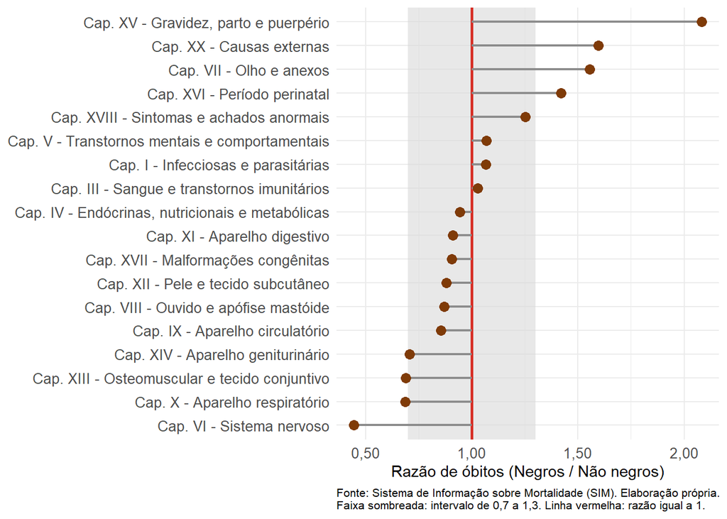

Figure 2.1: Razão entre óbitos da população negra e da população não negra por capítulo da CID, Brasil, 2019

Em 2019, os maiores volumes absolutos de óbitos foram registrados, tanto entre negros quanto entre não negros, nos capítulos das **doenças do aparelho circulatório**, das **causas externas** e das **doenças do aparelho respiratório**. Ainda assim, a comparação pela razão revela sobrerrepresentação da população negra sobretudo em **gravidez, parto e puerpério** e em **causas externas**, além de excesso relativo também em causas perinatais e em sintomas/achados inespecíficos. A literatura brasileira associa esse padrão à combinação entre racismo estrutural, barreiras de acesso oportuno e de qualidade aos serviços, maior exposição de jovens negros à violência letal e persistência de desigualdades na atenção à saúde sexual, reprodutiva e obstétrica (BRASIL, 2017; CERQUEIRA; BUENO, 2023; OLIVEIRA; KUBIAK, 2019; WERNECK, 2016). Por outro lado, o peso relativamente maior de óbitos por doenças respiratórias, do sistema nervoso e geniturinárias entre não negros é compatível com a estrutura etária mais envelhecida da população branca/não negra no Brasil, o que aumenta a participação de causas crônicas e degenerativas na mortalidade total (IBGE, 2023).

## 2.2 Evolução temporal da razão de óbitos por capítulo da CID

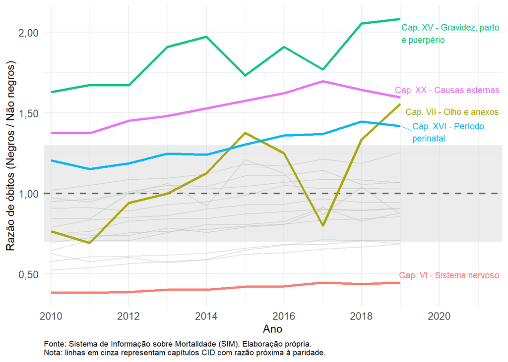

# 3 Cobertura de Planos de Saúde

A cobertura por plano de saúde privado constitui um dos indicadores mais diretos de acesso diferenciado a serviços de saúde, uma vez que determina a capacidade de acessar atendimentos eletivos, especializados e de diagnóstico fora do SUS. As desigualdades nessa cobertura refletem, em grande medida, as desigualdades de renda entre grupos raciais.

## 3.1 Evolução da Cobertura por Raça e Situação do Domicílio

A Figura 3.1 apresenta a cobertura de plano de saúde por raça, ano e situação do domicílio. No contexto urbano, a cobertura entre brancos manteve-se estável em torno de 41–42% tanto em 2013 quanto em 2019, enquanto entre negros ficou em 23%, revelando um gap racial de aproximadamente 18 pontos percentuais que não se reduziu no período.

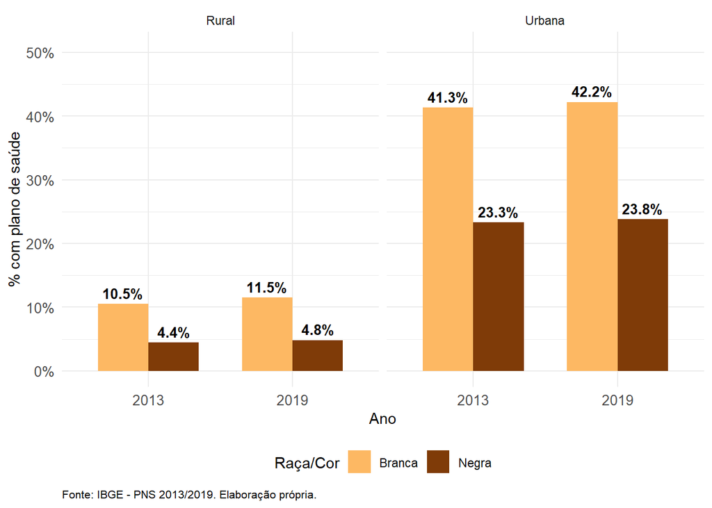

Figure 3.1: Cobertura de plano de saúde por raça e situação do domicílio — Brasil, PNS 2013/2019

No contexto rural, a cobertura é estruturalmente mais baixa para ambos os grupos, mas o gap racial é igualmente expressivo: brancos rurais passaram de 10,5% para 11,5%, enquanto negros rurais oscilaram entre 4,4% e 4,8%. A estagnação desse gap entre 2013 e 2019 indica que o crescimento econômico e as políticas do período não foram suficientes para reduzir as desigualdades raciais no acesso a planos de saúde privados. A população negra, majoritariamente dependente do SUS, está assim mais exposta às insuficiências da rede pública de saúde — o que torna as políticas de fortalecimento do SUS especialmente relevantes para a equidade racial.

# 4 Utilização de Serviços de Saúde

A utilização de serviços de saúde captura não apenas o acesso formal, mas também a efetiva demanda por cuidados, sendo influenciada por barreiras geográficas, econômicas, culturais e pelo racismo institucional que desencoraja ou prejudica o atendimento à população negra.

## 4.1 Atendimento de Urgência no Domicílio

A Figura 4.1 apresenta o percentual de pessoas com atendimento de urgência no domicílio por raça e ano. Em 2013, brancos e negros apresentaram percentual idêntico de 1,2%, mas em 2019 houve uma elevação desigual: brancos passaram a 2,2% e negros a 2,4%, indicando que a população negra passou a demandar ligeiramente mais esse tipo de serviço — possivelmente em razão de condições crônicas não controladas ou de menor acesso preventivo.

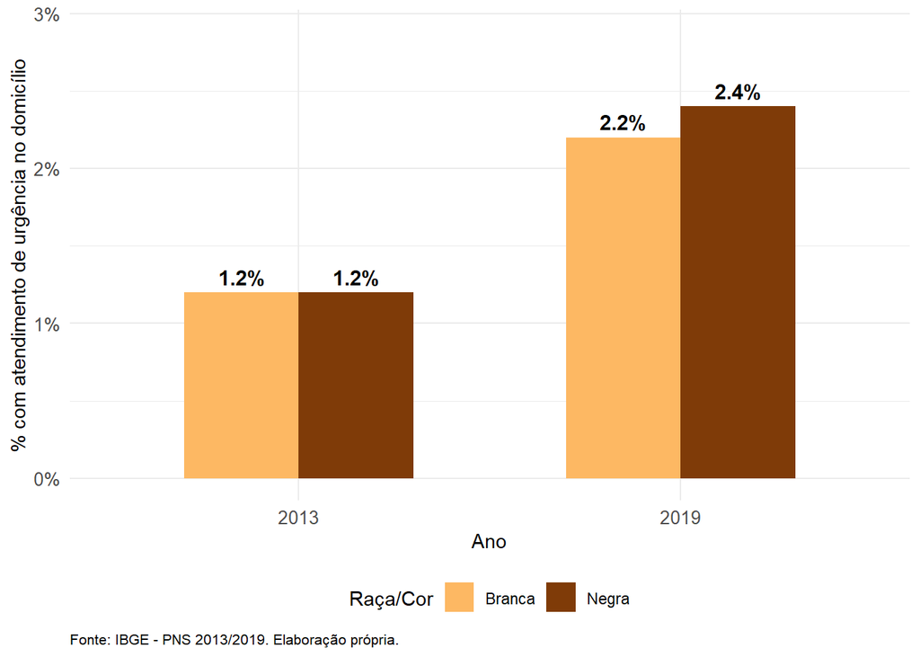

Figure 4.1: Atendimento de urgência no domicílio por raça — Brasil, PNS 2013/2019

O aumento entre 2013 e 2019 foi proporcionalmente maior entre os negros (+1,2 pp) do que entre os brancos (+1,0 pp), sugerindo uma piora relativa das condições de saúde que demandam atendimento emergencial. O atendimento de urgência no domicílio é, em geral, um indicador de falha na atenção primária: quando o cuidado preventivo e o manejo de condições crônicas funcionam adequadamente, os atendimentos de urgência diminuem. O crescimento desse indicador para a população negra é, portanto, um sinal de alarme sobre lacunas na atenção básica.

## 4.2 Consulta Médica

A Figura 4.2 apresenta o percentual que realizou consulta médica por raça em 2019. Os percentuais são praticamente idênticos entre brancos (87,5%) e negros (87,2%), diferença de apenas 0,3 ponto percentual.

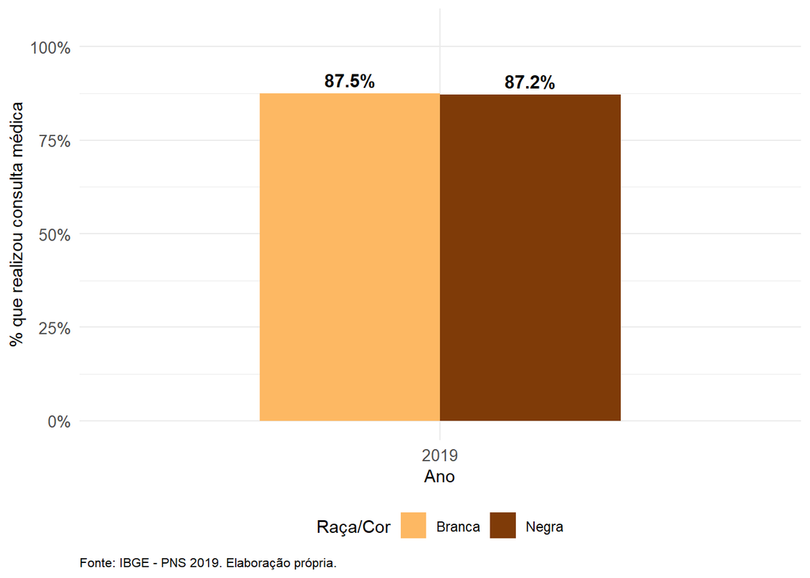

Figure 4.2: Realização de consulta médica por raça — Brasil, PNS 2019

A aparente equidade na realização de consultas médicas deve ser interpretada com cautela. Estudos qualitativos e dados de satisfação com serviços de saúde indicam que a qualidade e a resolubilidade do atendimento diferem significativamente por raça: a população negra acessa consultas predominantemente via SUS, com menor tempo de atendimento, menor probabilidade de solicitação de exames complementares e maior frequência de relatos de discriminação racial. Dessa forma, a igualdade quantitativa no acesso não implica igualdade na qualidade do cuidado recebido.

# 5 Acesso a Medicamentos no Sistema Público

O acesso a medicamentos no SUS é uma dimensão central da integralidade do cuidado, especialmente para populações com menor capacidade de arcar com gastos em saúde no mercado privado.

## 5.1 Obtenção de Medicamentos por Raça e Situação do Domicílio

A Figura 5.1 apresenta o percentual que obteve medicamento no serviço público por raça e situação do domicílio. No contexto rural, os percentuais são próximos entre brancos (38,0%) e negros (37,5%), sem diferença expressiva. No contexto urbano, porém, negros (32,7%) obtêm medicamentos no SUS em proporção maior do que brancos (26,9%).

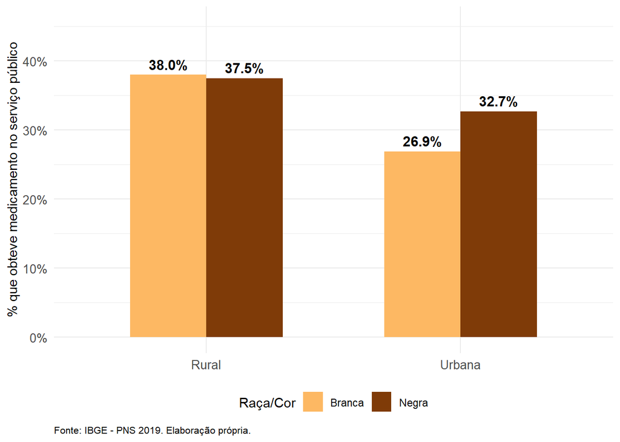

Figure 5.1: Obtenção de medicamentos no serviço público de saúde por raça e situação do domicílio — Brasil, PNS 2019

A Figura 5.2 isola o gap racial em pontos percentuais. No contexto urbano, o gap é de +5,8 pp (negros obtêm mais que brancos), enquanto no rural é de –0,5 pp (praticamente nulo).

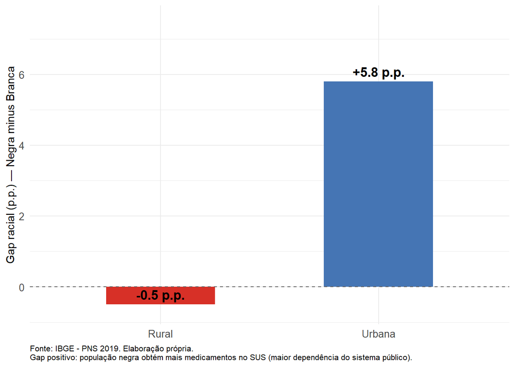

Figure 5.2: Gap racial no acesso a medicamentos no serviço público por situação do domicílio — Brasil, PNS 2019

O gap positivo no contexto urbano não indica vantagem da população negra, mas sim sua maior dependência estrutural do SUS para obtenção de medicamentos — reflexo da menor cobertura por planos de saúde e da menor capacidade de adquirir medicamentos no mercado privado. Ou seja, negros urbanos precisam mais do sistema público porque têm menos alternativas, o que reforça a importância de manter e ampliar a Assistência Farmacêutica no âmbito do SUS como política de equidade racial.

# 6 Deficiências e Diagnóstico de Autismo

A intersecção entre raça e deficiência constitui um eixo analítico ainda pouco explorado nas políticas públicas brasileiras, mas com implicações relevantes para o acesso a direitos, serviços especializados e proteção social.

## 6.1 Prevalência de Deficiência por Raça e Unidade da Federação

A Figura 6.1 apresenta as 15 UFs com maior gap racial na prevalência de deficiência. Em Alagoas, a prevalência entre negros chega a 10,6% contra 9,8% entre brancos; no Piauí, 10,1% vs. 9,7%. O padrão se repete nas demais UFs selecionadas: a população negra apresenta prevalência sistematicamente superior.

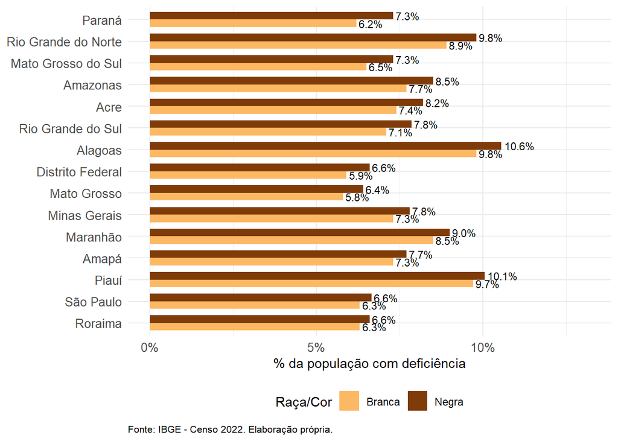

Figure 6.1: Prevalência de deficiência por raça nas UFs com maior gap racial — Brasil, Censo 2022

## 6.2 Diagnóstico de Autismo por Raça e Unidade da Federação

A Figura 6.2 apresenta as 15 UFs com maior gap no diagnóstico de autismo, com brancos sistematicamente acima de negros. No Amapá, 2,2% da população branca é diagnosticada com autismo contra 1,2% entre negros; no Acre, 2,1% vs. 1,4%.

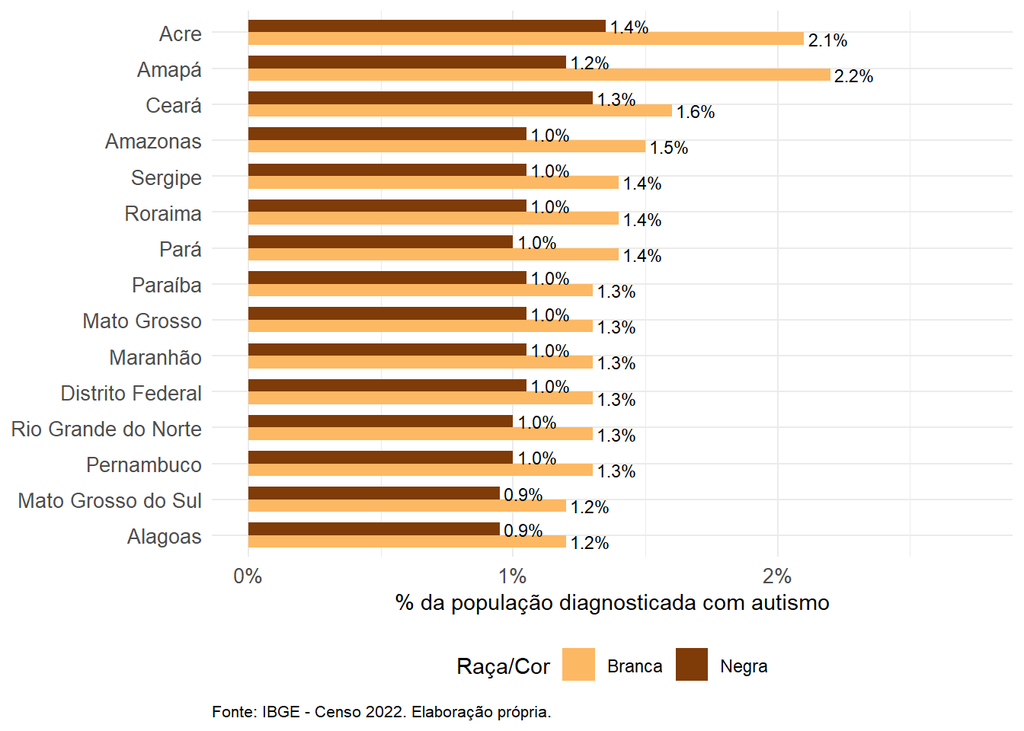

Figure 6.2: Prevalência de diagnóstico de autismo por raça nas UFs com maior gap racial — Brasil, Censo 2022

O padrão inverso observado para o autismo — brancos com maior prevalência de diagnóstico — não indica que o autismo seja mais frequente nesse grupo, mas sim que a população negra é sistematicamente subdiagnosticada. O subdiagnóstico resulta de múltiplos fatores: menor acesso a especialistas (neuropediatras, psicólogos, fonoaudiólogos), maior distância dos serviços de saúde especializados, menor familiaridade dos profissionais de saúde com as apresentações do autismo em crianças negras e, possivelmente, vieses diagnósticos associados ao racismo institucional. O subdiagnóstico de autismo na população negra tem consequências diretas sobre o acesso a serviços de educação especial, terapias e benefícios previdenciários, configurando uma forma invisível de exclusão.

# 7 Atenção Primária à Saúde para Crianças

A Atenção Primária à Saúde é a principal porta de entrada do SUS e o nível de cuidado com maior capacidade de reduzir iniquidades, ao oferecer acesso universal e próximo ao território. Analisar o uso de APS por crianças, por raça e região, permite identificar onde as desigualdades de acesso são mais agudas.

## 7.1 Composição Racial dos Atendimentos de APS por Grande Região

A Figura 7.1 apresenta a distribuição racial das crianças menores de 13 anos atendidas por médico na APS nos últimos 12 meses, por Grande Região. No Norte, 78,4% das crianças atendidas são negras e apenas 19,2% são brancas; no Nordeste, 73,3% vs. 25,5%. No Sul, o padrão se inverte: 30,8% negras e 69,0% brancas.

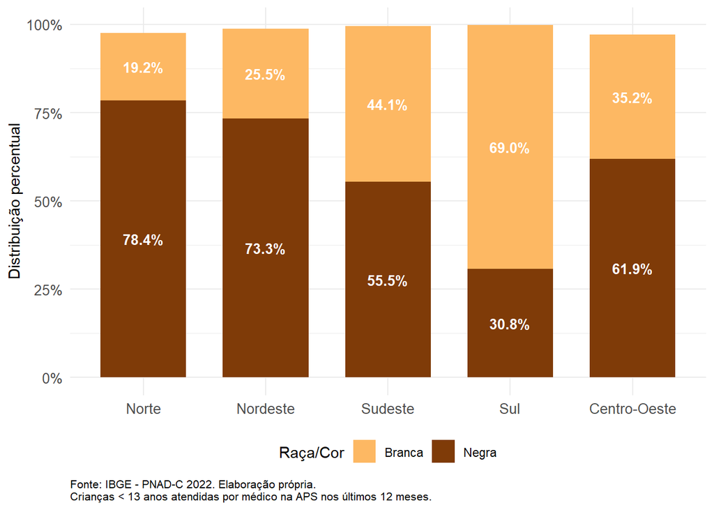

Figure 7.1: Composição racial das crianças menores de 13 anos atendidas na APS por Grande Região — Brasil, PNAD-C 2022

A Figura 7.2 isola o gap racial por região. O Norte apresenta o maior gap positivo (+59,2 pp), seguido pelo Nordeste (+47,8 pp) e Centro-Oeste (+26,7 pp). O Sul registra gap negativo (–38,2 pp), refletindo a composição demográfica majoritariamente branca da região.

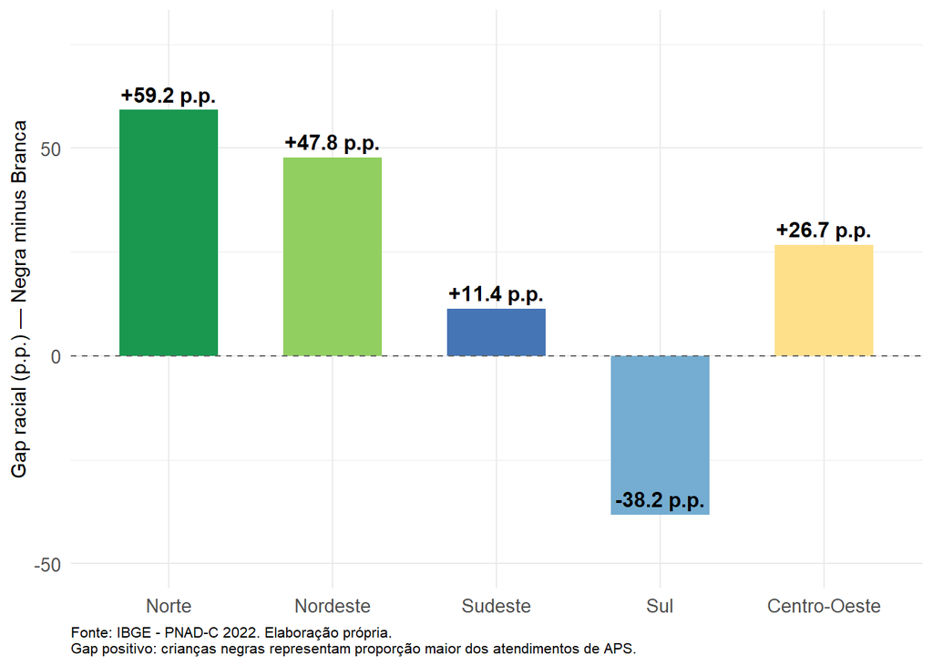

Figure 7.2: Gap racial no uso de APS por crianças por Grande Região — Brasil, PNAD-C 2022

Esses dados devem ser lidos em conjunto com a composição demográfica regional: o alto percentual de crianças negras nos atendimentos do Norte e Nordeste reflete, em parte, a predominância populacional negra nessas regiões. O indicador analiticamente mais relevante é a razão entre a proporção de crianças negras nos atendimentos de APS e a proporção de crianças negras na população total — um eventual subuso relativo indicaria barreiras de acesso. A análise do gap regional aponta, contudo, que o SUS cumpre papel redistributivo mais intenso exatamente nas regiões de maior concentração da população negra, o que reforça o argumento pela manutenção e fortalecimento da Estratégia Saúde da Família como política de equidade.

## 7.2 Considerações sobre Iniquidades em Saúde e Políticas Públicas

Os dados analisados neste texto compõem um quadro consistente de iniquidades raciais em saúde que atravessam dimensões distintas — cobertura, acesso, utilização, diagnóstico e cuidado especializado — configurando uma desvantagem acumulada para a população negra que não pode ser explicada por diferenças biológicas, mas que encontra sua origem nos determinantes sociais estruturais moldados pelo racismo histórico e institucional.

Os achados sobre o uso de APS por crianças, em particular o papel redistributivo do SUS nas regiões de maior concentração da população negra (Seção 7), reforçam a centralidade da articulação entre a política de saúde e a política de promoção da igualdade racial. Essa articulação é hoje institucionalmente mais viável do que em qualquer momento anterior, com a criação do Ministério da Igualdade Racial (MIR) em 2023, que assumiu competências antes dispersas entre diferentes pastas para a coordenação de políticas de promoção da igualdade racial. Recomenda-se que o MIR atue em conjunto com o Ministério da Saúde no monitoramento territorial do uso de APS por raça/cor — a exemplo do indicador de gap regional aqui construído —, subsidiando a alocação de recursos da Estratégia Saúde da Família e de programas de qualificação de equipes em territórios de maior concentração da população negra, bem como na pactuação de metas de equidade racial nos instrumentos de gestão do SUS (Planos de Saúde, Pactos Interfederativos).

A persistência do gap de 18 pontos percentuais na cobertura por plano de saúde entre brancos e negros urbanos, sem redução entre 2013 e 2019, indica que o crescimento econômico do período não foi suficiente para equalizar o acesso a serviços de saúde privados. A maior dependência da população negra do SUS, evidenciada pelo maior percentual de obtenção de medicamentos na rede pública (+5,8 pp no urbano), torna as políticas de fortalecimento e financiamento do SUS especialmente relevantes para a equidade racial. Cortes no orçamento da saúde pública afetam desproporcionalmente a população negra, que tem menos alternativas no setor privado.

O subdiagnóstico de autismo entre negros — gap de até 1,0 pp em relação aos brancos em estados como Amapá e Acre — e a maior prevalência de deficiências entre negros em praticamente todas as UFs analisadas revelam duas faces complementares da iniquidade: de um lado, a maior exposição a condições de vida que produzem deficiências; de outro, o menor acesso ao diagnóstico especializado que permitiria acessar direitos e serviços. Ambas as situações demandam políticas específicas no âmbito da PNSIPN, incluindo ampliação de centros especializados em regiões de maior concentração da população negra e formação antirracista de profissionais de saúde.

Para avançar na redução dessas iniquidades, são necessárias ações em múltiplos níveis: (i) fortalecimento da Estratégia Saúde da Família como principal instrumento de cuidado primário para a população negra, especialmente no Norte e Nordeste; (ii) ampliação da Assistência Farmacêutica do SUS, garantindo acesso equitativo a medicamentos para populações sem cobertura de plano; (iii) criação de protocolos de triagem e diagnóstico de autismo e outras condições do neurodesenvolvimento que considerem expressões culturalmente situadas e reduzam vieses raciais; (iv) fortalecimento da vigilância epidemiológica com recorte racial, para monitorar a evolução das iniquidades e avaliar o impacto das políticas; e (v) implementação efetiva da PNSIPN em todos os entes federativos, com metas mensuráveis de redução do gap racial nos indicadores de saúde.

# 8 Mortalidade por Causas e a Implementação da PNSIPN

A Política Nacional de Saúde Integral da População Negra (PNSIPN), instituída em 2009, é citada ao longo deste texto como referência normativa para a equidade racial no SUS, mas sua implementação efetiva — e não apenas sua existência formal — precisa ser avaliada empiricamente. Esta seção combina duas fontes para essa avaliação: o Sistema de Informações sobre Mortalidade (SIM/DATASUS), que registra as causas de óbito por capítulo da CID-10 e por raça/cor desde 1996, e a Pesquisa de Informações Básicas Municipais (MUNIC/IBGE) de 2021, que perguntou diretamente aos municípios brasileiros se implementaram ações da PNSIPN. Com o SIM, examinam-se (i) a completude do quesito raça/cor nas declarações de óbito, pré-condição para qualquer monitoramento racial da mortalidade; e (ii) a evolução do gap racial na mortalidade por causas externas. Com a MUNIC, examina-se diretamente (iii) o grau de institucionalização da PNSIPN nos municípios brasileiros — a medida mais direta de implementação disponível nas bases de dados públicas.

## 8.1 Completude do Quesito Raça/Cor nas Declarações de Óbito

A Figura 8.1 apresenta a evolução do percentual de óbitos registrados no SIM sem informação de raça/cor (“Ignorado/Sem informação”) entre 1996 e 2019. A linha vertical tracejada indica o ano de instituição da PNSIPN (2009).

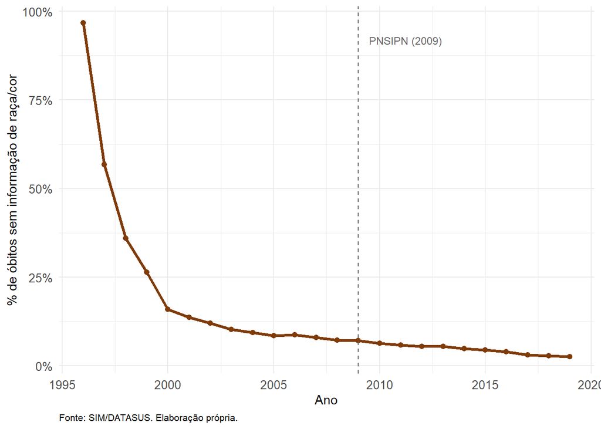

Figure 8.1: Percentual de Óbitos sem Informação de Raça/Cor no SIM — Brasil, 1996-2019

A redução da incompletude do quesito raça/cor ao longo do período é uma pré-condição para que o SUS e a PNSIPN consigam, de fato, monitorar as iniquidades raciais em saúde — um sistema de informação que não identifica a raça/cor do óbito não permite calcular gaps, tendências ou avaliar políticas. A persistência de um percentual não nulo de registros sem essa informação, mesmo na década seguinte à instituição da PNSIPN, configura uma lacuna concreta de implementação: a política prevê, entre suas diretrizes, o aprimoramento dos sistemas de informação em saúde quanto ao quesito raça/cor, mas a efetivação completa dessa diretriz nos cartórios e serviços de saúde responsáveis pelo preenchimento das declarações de óbito permanece incompleta.

## 8.2 Mortalidade por Causas Externas e o Gap Racial

A Figura 8.2 apresenta a evolução do percentual de óbitos por causas externas (capítulo XX da CID-10) entre a população negra e não negra, de 1996 a 2019.

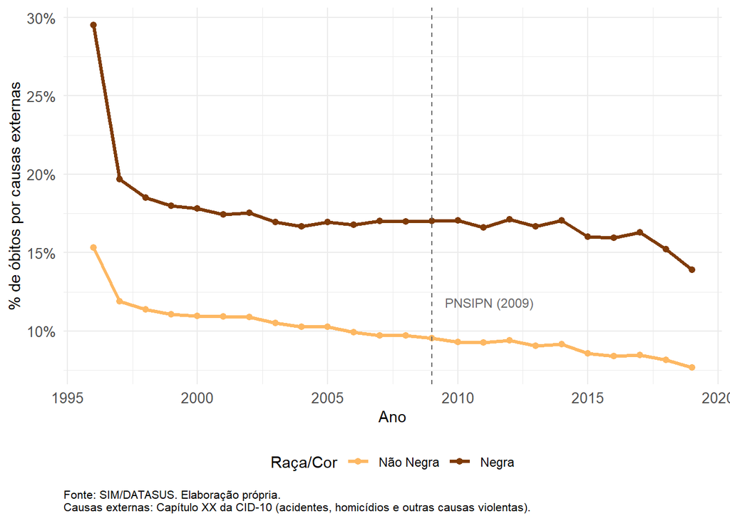

Figure 8.2: Percentual de Óbitos por Causas Externas, por Raça/Cor — Brasil, 1996-2019

A população negra apresenta, em praticamente todo o período analisado, percentual de óbitos por causas externas superior ao da população não negra, refletindo a sobreposição entre racismo estrutural, violência urbana e exposição diferencial a contextos de risco. A instituição da PNSIPN em 2009 não corresponde, nos dados, a uma inflexão visível na trajetória desse gap — o que é coerente com a literatura sobre a implementação da política, que aponta descontinuidade de financiamento, baixa adesão de estados e municípios aos planos de ação e ausência de metas vinculantes como obstáculos centrais à efetividade da PNSIPN. Isso sugere que a existência formal da política, embora necessária, não é suficiente: sua efetividade depende de mecanismos de financiamento estável, monitoramento independente e responsabilização federativa, dimensões que extrapolam o escopo sanitário e dialogam diretamente com a agenda de promoção da igualdade racial conduzida pelo Ministério da Igualdade Racial (MIR), conforme discutido na Seção 7.2.

## 8.3 Implementação Institucional da PNSIPN nos Municípios

As subseções anteriores avaliam a implementação da PNSIPN de forma indireta, a partir de seus efeitos sobre indicadores de mortalidade. A Pesquisa de Informações Básicas Municipais (MUNIC/IBGE), no levantamento sobre saúde da população negra, permite uma avaliação direta: ela perguntou a todos os municípios brasileiros se incorporaram ações da PNSIPN ao Plano Municipal de Saúde, se possuem setor ou coordenação dedicada ao tema, se desenvolvem programas específicos e se capacitam profissionais de saúde sobre saúde da população negra e antirracismo.[^1]

A Figura 8.3 apresenta o percentual de municípios brasileiros que atendem a cada um desses quatro critérios.

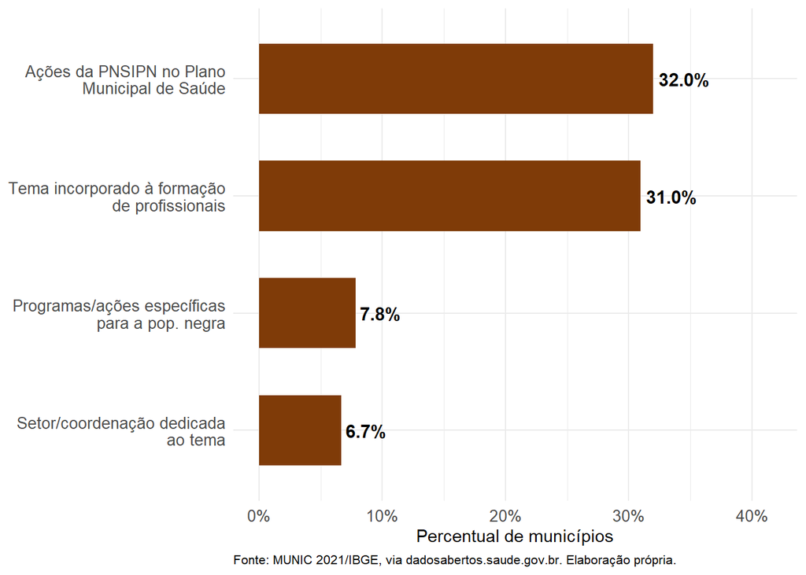

Figure 8.3: Implementação Institucional da PNSIPN nos Municípios Brasileiros — MUNIC 2021

Os resultados revelam uma lacuna substancial entre a existência formal da PNSIPN — instituída em 2009 — e sua efetiva institucionalização na ponta do SUS: a maioria dos municípios brasileiros não incorporou ações da política a seus Planos Municipais de Saúde, não possui setor ou coordenação dedicada ao tema, e não desenvolve programas específicos para a saúde da população negra. Essa constatação direta de implementação incompleta complementa a evidência indireta apresentada anteriormente nesta seção: a estagnação do gap racial na mortalidade por causas externas não é surpreendente à luz da baixa capilaridade municipal da política.

## 8.4 Implementação da PNSIPN e Desigualdade Racial Territorial

A Figura 8.4 desagrega os mesmos quatro indicadores por região, permitindo verificar se a implementação da PNSIPN acompanha a distribuição territorial da população negra no país — que, como discutido em outros textos deste produto, é proporcionalmente maior nas regiões Norte e Nordeste.

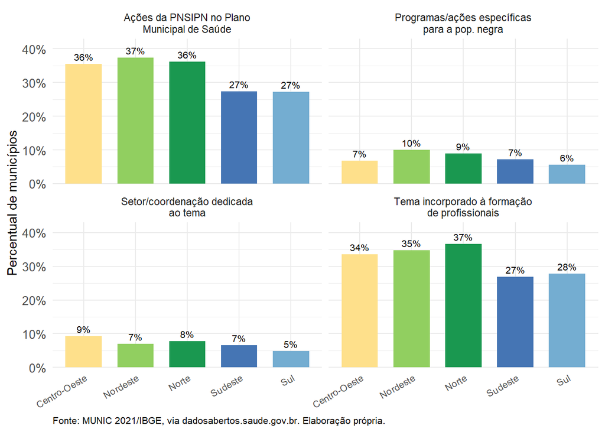

Figure 8.4: Implementação Institucional da PNSIPN por Região — MUNIC 2021

# Referências

BRASIL. Ministério da Saúde. *Política Nacional de Saúde Integral da População Negra: uma política para o SUS*. 3. ed. Brasília: Editora do Ministério da Saúde, 2017.

BRASIL. Ministério da Saúde. *Sistema de Informações sobre Mortalidade (SIM)*. Brasília: DATASUS, [s.d.]. Disponível em: datasus.saude.gov.br.

IBGE. *Pesquisa de Informações Básicas Municipais (MUNIC) 2021 — Saúde da População Negra*. Dataset “[MGDI] Saúde da População Negra”. Brasília: Ministério da Saúde, [s.d.]. Disponível em: dadosabertos.saude.gov.br.

CERQUEIRA, Daniel; BUENO, Samira (coord.). *Atlas da violência 2023*. Brasília: Ipea; FBSP, 2023.

CHOR, Dóra; LIMA, Claudia Risso de Araújo. Aspectos epidemiológicos das desigualdades raciais em saúde no Brasil. *Cadernos de Saúde Pública*, v. 21, n. 5, p. 1586-1594, 2005.

GOES, Emanuelle Freitas; FERREIRA, Andrea Jacqueline Fortes; WALDMAN, Eliseu Alves. Desigualdades raciais em saúde e a pandemia da Covid-19. *Trabalho, Educação e Saúde*, v. 18, n. 3, 2020.

IBGE. *Censo Demográfico 2022*. Rio de Janeiro: IBGE, 2023.

IBGE. *Pesquisa Nacional de Saúde 2013 e 2019*. Rio de Janeiro: IBGE, 2014; 2020.

IBGE. *Pesquisa Nacional por Amostra de Domicílios Contínua — Anual 2022*. Rio de Janeiro: IBGE, 2023.

KALCKMANN, Suzana et al. Racismo institucional: um desafio para a equidade no SUS. *Saúde e Sociedade*, v. 16, n. 2, p. 146-155, 2007.

LOPES, Fernanda. Para além da barreira dos números: desigualdades raciais e saúde. *Cadernos de Saúde Pública*, v. 21, n. 5, p. 1595-1601, 2005.

OLIVEIRA, Beatriz Muccini Costa; KUBIAK, Fabiana. Racismo institucional e a saúde da mulher negra: uma análise da produção científica brasileira. *Saúde em Debate*, v. 43, n. 122, p. 939-948, 2019.

ORGANIZAÇÃO MUNDIAL DA SAÚDE. *Comissão sobre Determinantes Sociais da Saúde: relatório final*. Genebra: OMS, 2008.

WERNECK, Jurema. Racismo institucional e saúde da população negra. *Saúde e Sociedade*, v. 25, n. 3, p. 535-549, 2016.

[^1]: Dados do levantamento MUNIC 2021, dataset “[MGDI] Saúde da População Negra” (dadosabertos.saude.gov.br). Os quatro indicadores binários utilizados aqui (`spnmap`, `spnmcr`, `spnmpr`, `spnmst`) indicam, respectivamente, a existência de ações da PNSIPN no Plano Municipal de Saúde, a incorporação do tema na formação de profissionais, a existência de programas/ações específicas e a existência de setor/coordenação dedicada — para os 5.570 municípios brasileiros.